# Business Statistics End of Term Assessment IB94X0 2024-2025 #1

5646570

## Academic Integrity Statement

This work adheres to the principles of academic integrity as outlined by the University of Warwick. I affirm that the analysis and results presented in this assignment are my own, with all sources appropriately credited. I understand that acts of academic misconduct, such as plagiarism, collusion, or contract cheating, violate the university’s regulations and may result in serious consequences. By following the guidelines provided, I strive to maintain the highest standards of honesty and integrity in my academic work, reflecting the values upheld by the University.

## Declaration of use of AI

AI used: ChatGPT

*Why AI was used*: I used AI assistance for enhancing certain aspects of the R code, such as refining syntax for plotting, improving code efficiency, and addressing minor technical errors.

*Which AI was used:* ChatGPT by OpenAI.

*What AI was used for*: 1. To debug and rectify errors within the code while validating the quality and integrity of the dataset. 2. To learn methods for embedding images in R Markdown files, including the syntax for saving plots with ggsave() and png() and using include_graphics() for final report presentation. 3. To explore plotting techniques and various colour pallete available. 4.To gain insights into possible visualization approaches in R to ensure the results are presented clearly and professionally.

*Use of generated content in submission:* *No content generated by AI has been directly* included in this submission. AI was utilized to produce example code, which I then interpreted and adapted to fit the specific requirements of this data and report. I confirm that no significant portion of the work submitted here has been submitted by me for any other assessments in accredited courses.

The AI tool was utilized purely for guidance and learning purposes in code implementation, visualization decisions, and presentation techniques.

## Question 1:

This report **examines the key factors influencing cardiovascular disease (CVD) prevalence in England, with a focus on poverty, smoking rates, overweight prevalence, and wellbeing**. Through statistical methods such as multiple regression and correlation analysis, the aim is to provide clear insights to guide public health strategies.

## Question 2:

This analysis explores the factors influencing customer satisfaction in a furniture retail company. Using statistical techniques such as linear regression, interaction modeling, and ANOVA, the study examines the effects of staff satisfaction, delivery time, and socioeconomic status (SES) on customer satisfaction.

## Question 1 report:

### 1. Introduction

The objective of this analysis is **to identify the key predictors of cardiovascular disease (CVD) prevalence in England. Specifically, we examine how poverty, smoking rates, overweight prevalence, and wellbeing influence CVD**.

The dataset includes metrics for each region, and multiple regression analysis, combined with correlation analysis, is employed to understand these relationships. The results are presented using NHST (Null Hypothesis Significance Testing) and summarized in plain English to facilitate actionable insights.

```r
# Creating data description table
data_description <- data.frame(
  Variable = c("CVD", "Poverty", "overweight", "smokers", "wellbeing", "area Name", "area Code"),
  Description = c(
    "Prevalence of cardiovascular disease in the region (%)",
    "Percentage of the population living below the poverty line (%)",
    "Percentage of the population classified as overweight (%)",
    "Percentage of the population identified as smokers (%)",
    "Composite score measuring overall quality of life (higher is better)",
    "Name of the geographical area/region",
    "Unique identifier for the geographical area"
  )
)

# Displaying the data description table for better understanding purposes
kable(data_description, align = "l", caption = "Data Description Table")
```

Data Description Table

| Variable | Description |
| --- | --- |
| CVD | Prevalence of cardiovascular disease in the region (%) |
| Poverty | Percentage of the population living below the poverty line (%) |
| overweight | Percentage of the population classified as overweight (%) |
| smokers | Percentage of the population identified as smokers (%) |
| wellbeing | Composite score measuring overall quality of life (higher is better) |
| area Name | Name of the geographical area/region |
| area Code | Unique identifier for the geographical area |

### 2. Data Preparation

#### 2.1 Variables Overview

Description of the selected variables (CVD, Poverty, overweight, smokers, wellbeing).

#### 2.2 Loading and Cleaning the Data

2.2.1 Cleaning and handling missing values.

2.2.2 Final checks for data integrity.

#### 2.3 No missing values remain after cleaning.

```
## 'data.frame':    385 obs. of  8 variables:
##  $ area_name : chr  "Hartlepool" "Middlesbrough" "Redcar and Cleveland" "Stockton-on-Tees" ...
##  $ area_code : chr  "E06000001" "E06000002" "E06000003" "E06000004" ...
##  $ Population: int  88905 133375 131035 186365 104300 125725 205450 147180 134135 249770 ...
##  $ Poverty   : num  23 25.1 21.4 19.5 19.7 21.9 17.9 24.9 26.1 22.4 ...
##  $ CVD       : num  13.7 13.1 15 12.4 11.9 15.7 12 13.4 17.6 11.2 ...
##  $ overweight: num  34.6 32 33.4 40.2 35.7 ...
##  $ smokers   : num  17.3 17.9 13.3 12.5 10.6 13.2 10 15.5 20.6 22 ...
##  $ wellbeing : num  7.33 7.21 7.44 7.4 7.25 7.29 7.21 7.43 7.16 7.14 ...
```

```
##   area_name          area_code           Population         Poverty
##  Length:385         Length:385         Min.   :   1960   Min.   :12.90
##  Class :character   Class :character   1st Qu.: 100640   1st Qu.:16.90
##  Mode  :character   Mode  :character   Median : 135275   Median :18.70
##                                        Mean   : 174804   Mean   :19.34
##                                        3rd Qu.: 216600   3rd Qu.:21.40
##                                        Max.   :1056970   Max.   :30.70
##                                        NA's   :76        NA's   :76
##       CVD          overweight       smokers        wellbeing
##  Min.   : 7.90   Min.   :10.24   Min.   : 3.20   Min.   :6.610
##  1st Qu.:10.90   1st Qu.:21.63   1st Qu.:10.72   1st Qu.:7.280
##  Median :12.30   Median :25.52   Median :12.80   Median :7.410
##  Mean   :12.42   Mean   :25.52   Mean   :13.07   Mean   :7.423
##  3rd Qu.:14.10   3rd Qu.:29.46   3rd Qu.:15.30   3rd Qu.:7.560
##  Max.   :17.80   Max.   :40.22   Max.   :27.80   Max.   :8.170
##  NA's   :76      NA's   :72      NA's   :7       NA's   :15
```

```
## [1] 0
```

```
##  area_name  area_code Population    Poverty        CVD overweight    smokers
##          0          0         76         76         76         72          7
##  wellbeing
##         15
```

```
## 'data.frame':    303 obs. of  6 variables:
##  $ area_name : chr  "Hartlepool" "Middlesbrough" "Redcar and Cleveland" "Stockton-on-Tees" ...
##  $ Poverty   : num  23 25.1 21.4 19.5 19.7 21.9 17.9 24.9 26.1 22.4 ...
##  $ CVD       : num  13.7 13.1 15 12.4 11.9 15.7 12 13.4 17.6 11.2 ...
##  $ overweight: num  34.6 32 33.4 40.2 35.7 ...
##  $ smokers   : num  17.3 17.9 13.3 12.5 10.6 13.2 10 15.5 20.6 22 ...
##  $ wellbeing : num  7.33 7.21 7.44 7.4 7.25 7.29 7.21 7.43 7.16 7.14 ...
##  - attr(*, "na.action")= 'omit' Named int [1:82] 50 58 59 60 61 62 63 161 162 176 ...
##   ..- attr(*, "names")= chr [1:82] "50" "58" "59" "60" ...
```

```
##   area_name            Poverty           CVD          overweight
##  Length:303         Min.   :12.90   Min.   : 7.90   Min.   :10.24
##  Class :character   1st Qu.:16.95   1st Qu.:10.90   1st Qu.:21.65
##  Mode  :character   Median :18.70   Median :12.30   Median :25.63
##                     Mean   :19.36   Mean   :12.45   Mean   :25.54
##                     3rd Qu.:21.45   3rd Qu.:14.15   3rd Qu.:29.54
##                     Max.   :30.70   Max.   :17.80   Max.   :40.22
##     smokers        wellbeing
##  Min.   : 3.70   Min.   :6.610
##  1st Qu.:10.50   1st Qu.:7.275
##  Median :12.60   Median :7.410
##  Mean   :12.87   Mean   :7.417
##  3rd Qu.:15.20   3rd Qu.:7.545
##  Max.   :27.80   Max.   :8.100
```

```
##  area_name    Poverty        CVD overweight    smokers  wellbeing
##          0          0          0          0          0          0
```

### 3 Exploratory Data Analysis (EDA)

#### 3.1 Distribution of Variables

3.1.1 We visualized the distributions of key variables to assess normality and variability. 3.1.2 Histograms help check for normality, skewness, and outliers, which are critical for ensuring the validity of parametric statistical tests like regression.

```
##    CVD Poverty overweight smokers
## 1 TRUE    TRUE       TRUE    TRUE
```

#### 3.4 Graphical Interpretation

3.4.1 *CVD Prevalence*: The histogram shows an approximately normal distribution, with most regions having a moderate CVD prevalence, making it ideal for regression.

3.4.2 *Overweight and Wellbeing*: Both exhibit bell-shaped distributions, suggesting evenly distributed rates across regions.

3.4.3 *Poverty*: Slightly right-skewed, indicating some regions have high poverty levels. However, the overall distribution is symmetric enough for reliable analysis.

3.4.4 *Smokers*: Moderately skewed, with most regions having lower smoking rates. A few regions exhibit higher percentages, potentially influencing CVD prevalence.

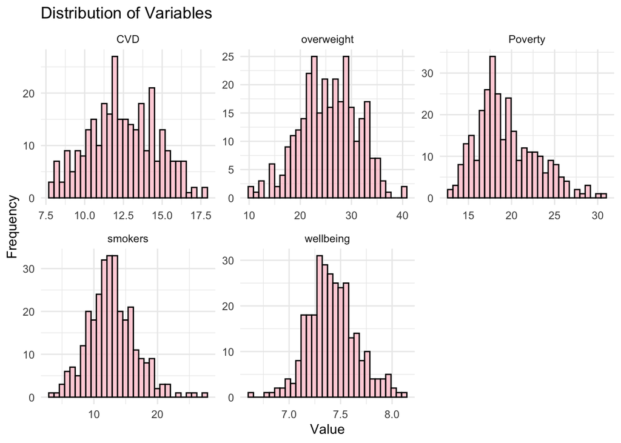

#### 3.5 Descriptive Statistics:

3.5.1 The variables (CVD, Poverty, overweight, smokers, and wellbeing) are all continuous and approximately normally distributed (confirmed through histograms). Pearson correlation is appropriate under these conditions, as it assumes linearity and normality.

3.5.2 **Pearson correlation** is widely used and easy to interpret, making it suitable for public reporting and comparisons.

```r
# Performing Pearson Correlation Analysis between each predictor and CVD
cor_matrix <- cor(cvd_clean_dataset[c("CVD", "Poverty", "overweight", "smokers", "wellbeing")], method = "pearson")
print(cor_matrix)
```

```
##                   CVD    Poverty  overweight    smokers   wellbeing
## CVD         1.0000000 -0.2480841  0.31900420  0.1778206  0.24536584
## Poverty    -0.2480841  1.0000000  0.13933765  0.3613067 -0.34510391
## overweight  0.3190042  0.1393377  1.00000000  0.4033591 -0.04183724
## smokers     0.1778206  0.3613067  0.40335911  1.0000000 -0.19895474
## wellbeing   0.2453658 -0.3451039 -0.04183724 -0.1989547  1.00000000
```

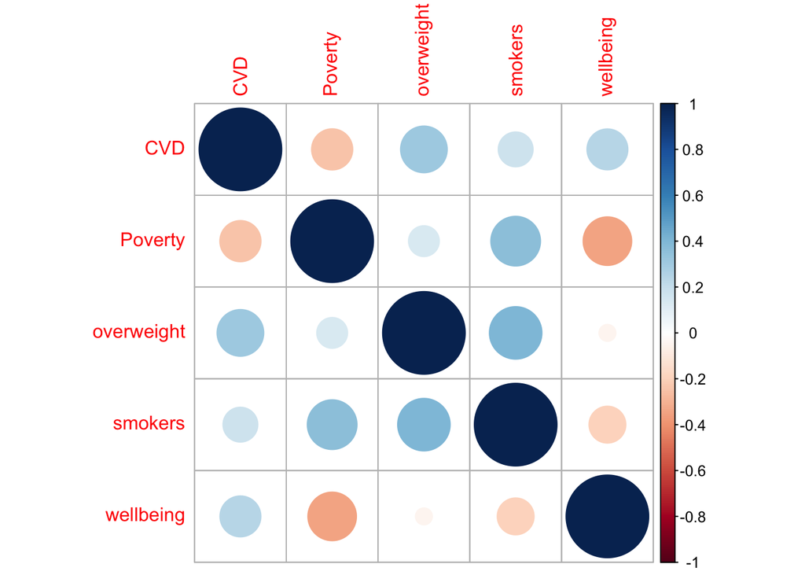

```r
# Performing a visualization of the resulting correlation matrix of each predictor using corrplot
corrplot(cor_matrix, method = "circle")
```

### 4 Correlation Matrix

#### *Key Observations from Correlation Analysis*:

**Poverty and Smokers**: Higher poverty is *moderately associated with increased smoking rates*, potentially compounding health risks.

**Moderate Correlations**:

**Overweight and CVD**: A moderately positive relationship indicates that overweight prevalence contributes to higher CVD rates, *highlighting the role of obesity management in public health strategies*.

### 5 Regression Analysis

#### 5.1 **Multiple Linear Regression**:

To quantify the unique contribution of each predictor to CVD prevalence while accounting for the influence of other predictors.

#### 5.2 **Interpretation of Results**:

5.2.2 **Overweight** (p<0.001): **Highly Significant**. A positive relationship shows that a 1% increase in overweight prevalence is associated with a 0.1099% increase in CVD prevalence.

5.2.5 Regression provides precise estimates (β) of how much each predictor influences CVD prevalence, enabling actionable insights.

```r
# Performing Multiple regression analysis
model_cvd <- lm(CVD ~ Poverty + overweight + smokers + wellbeing, data = cvd_clean_dataset)
summary(model_cvd)
```

```
##
## Call:
## lm(formula = CVD ~ Poverty + overweight + smokers + wellbeing,
##     data = cvd_clean_dataset)
##
## Residuals:
##     Min      1Q  Median      3Q     Max
## -4.3966 -1.4313 -0.1097  1.3905  4.7779
##
## Coefficients:
##             Estimate Std. Error t value Pr(>|t|)
## (Intercept) -1.69780    3.93361  -0.432 0.666335
## Poverty     -0.18400    0.03515  -5.234 3.13e-07 ***
## overweight   0.10985    0.02123   5.174 4.22e-07 ***
## smokers      0.12030    0.03366   3.574 0.000410 ***
## wellbeing    1.80025    0.49096   3.667 0.000291 ***
## ---
## Signif. codes:  0 '***' 0.001 '**' 0.01 '*' 0.05 '.' 0.1 ' ' 1
##
## Residual standard error: 1.894 on 298 degrees of freedom
## Multiple R-squared:  0.2494, Adjusted R-squared:  0.2393
## F-statistic: 24.75 on 4 and 298 DF,  p-value: < 2.2e-16
```

```r
# Performing a check for multi-collinearity using Variance Inflation Factor (VIF)
vif(model_cvd)
```

```
##    Poverty overweight    smokers  wellbeing
##   1.263094   1.196546   1.359206   1.145506
```

#### 5.3 **Multicolinearity Check**:

Using VIF (Variance Inflation Factor): To ensure that the predictors (Poverty, overweight, smokers, wellbeing) are not highly correlated with each other, which could compromise the interpretability and validity of the regression model.

5.3.1 **All VIF scores are below 5**, indicating no significant multicollinearity among the predictors, which validates the use of multiple linear regression for this analysis.

5.3.2 Ensures the reliability of the regression results, further supporting its use over ANOVA.

### 6 Visualization of Results

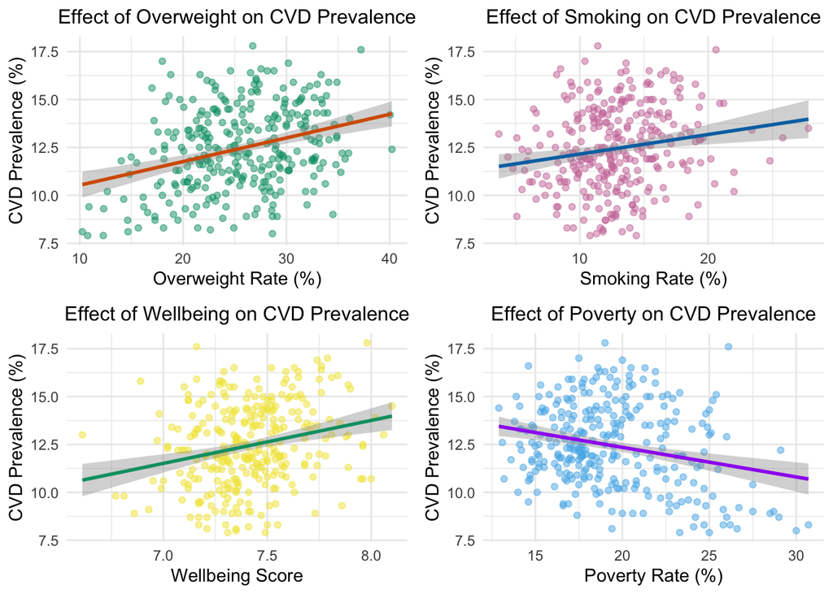

#### 6.1 Overweight vs. CVD:

- The orange regression line indicates a moderate positive relationship, with regions having higher overweight prevalence also showing higher CVD rates.
- Most data points cluster near the mean, suggesting a consistent effect.
- Outliers in the upper-right quadrant (high overweight and high CVD prevalence) highlight regions needing further analysis.

**Conclusion: Overweight prevalence is a critical behavioral factor influencing CVD, supporting the need for obesity management programs.**

#### 6.2 Smokers vs. CVD:

- The blue regression line shows a weak to moderate positive relationship, indicating that smoking rates are positively associated with CVD prevalence.
- Data points are more dispersed, reflecting greater variability in the relationship.

**Conclusion: Smoking behavior contributes to CVD prevalence, particularly in high-smoking regions, but its impact is smaller compared to poverty and overweight.**

#### 6.4 Poverty vs. CVD:

**Conclusion: Poverty is the strongest predictor of CVD, underscoring the need for targeted public health interventions in high-poverty regions.**

### 7. Effect of Poverty on CVD

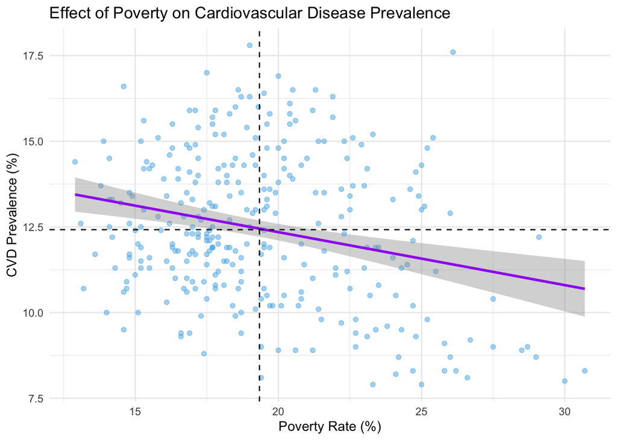

### 8. Executive Summary

This report investigates the socioeconomic and behavioral predictors of cardiovascular disease (CVD) prevalence in England, **focusing on poverty, smoking rates, overweight prevalence, and wellbeing scores**.

### 9. Conclusion

1. **Poverty** has the most significant impact on CVD prevalence, emphasizing the critical role of socioeconomic inequalities.
2. **Overweight and Smoking** are notable contributors to CVD, reflecting the importance of addressing behavioral risk factors.
3. **Wellbeing** There is an unexpectedly weak positive correlation observed. Ideally, higher wellbeing scores would be expected to reduce CVD cases, indicating a negative correlation; however, this is not reflected here. This discrepancy suggests that the “wellbeing” measure may not fully capture the factors that contribute to mitigating CVD risk. ______________________________________________________________________________________________________

## Question 2 report:

### 1. Introduction

Customer satisfaction is a vital metric for retail businesses, directly influencing customer loyalty and overall performance.

Key aspects of the analysis include: • Evaluating the impact of staff.satisfaction, delivery.time, new_range, and SES_category on customer.satisfaction. • Exploring whether the relationship between delivery.time and customer.satisfaction varies across socioeconomic categories using interaction modeling. • Validating the dataset to ensure quality and consistency. • Visualizing key variables and relationships for better insights. • Applying linear regression and interaction models, with results interpreted using Null Hypothesis Significance Testing (NHST).

The findings, presented through tables, figures, and statistical results, provide actionable insights to enhance customer satisfaction across diverse store contexts.

**Data Description table creation**

Each variable in the dataset is described in a table to provide clarity about its nature and role. This ensures a clear understanding of the dataset before beginning the analysis.

```r
# Creating data description table
data_description <- data.frame(
  Variable = c("customer_satisfaction", "staff_satisfaction", "delivery_time", "product_range", "SES"),
  Description = c(
    "Average customer satisfaction score (0-10 scale)",
    "Average staff job satisfaction score (0-10 scale)",
    "Average delivery time for large and custom items (in days)",
    "Indicator for whether the store carries a new product range (Yes/No)",
    "Socio-economic status of the store location (Low/Medium/High)"
  )
)

# Displaying the data description table for better understanding purposes
kable(data_description, align = "l", caption = "Data Description Table")
```

Data Description Table

| Variable | Description |
| --- | --- |
| customer_satisfaction | Average customer satisfaction score (0-10 scale) |
| staff_satisfaction | Average staff job satisfaction score (0-10 scale) |
| delivery_time | Average delivery time for large and custom items (in days) |
| product_range | Indicator for whether the store carries a new product range (Yes/No) |
| SES | Socio-economic status of the store location (Low/Medium/High) |

### 3. Data Exploration

**Purpose**: - These steps ensure the dataset is formatted appropriately for statistical modeling and align with the requirements for conducting accurate regression analysis.

```
## 'data.frame':    300 obs. of  5 variables:
##  $ SES_category         : chr  "Medium" "Medium" "Medium" "High" ...
##  $ customer.satisfaction: num  7.27 7.93 7.12 6.35 6.78 ...
##  $ staff.satisfaction   : num  6.88 7.44 7.15 6.47 7.06 ...
##  $ delivery.time        : num  66.7 68.2 70.7 61.4 57.7 ...
##  $ new_range            : logi  FALSE FALSE FALSE TRUE TRUE TRUE ...
```

```
##  SES_category       customer.satisfaction staff.satisfaction delivery.time
##  Length:300         Min.   :3.760         Min.   :4.850      Min.   :32.96
##  Class :character   1st Qu.:6.099         1st Qu.:6.216      1st Qu.:52.46
##  Mode  :character   Median :7.006         Median :6.634      Median :60.45
##                     Mean   :6.930         Mean   :6.751      Mean   :59.60
##                     3rd Qu.:7.865         3rd Qu.:7.274      3rd Qu.:66.79
##                     Max.   :9.670         Max.   :8.860      Max.   :92.48
##  new_range
##  Mode :logical
##  FALSE:142
##  TRUE :158
##
##
##
```

```
## [1] 0
```

```
## [1] 0
```

```
## 'data.frame':    300 obs. of  5 variables:
##  $ SES_category         : chr  "Medium" "Medium" "Medium" "High" ...
##  $ customer.satisfaction: num  7.27 7.93 7.12 6.35 6.78 ...
##  $ staff.satisfaction   : num  6.88 7.44 7.15 6.47 7.06 ...
##  $ delivery.time        : num  66.7 68.2 70.7 61.4 57.7 ...
##  $ new_range            : logi  FALSE FALSE FALSE TRUE TRUE TRUE ...
```

```
## Converted SES_category to factor.
```

```
## 'data.frame':    300 obs. of  5 variables:
##  $ SES_category         : Factor w/ 3 levels "High","Low","Medium": 3 3 3 1 1 3 3 3 3 1 ...
##  $ customer.satisfaction: num  7.27 7.93 7.12 6.35 6.78 ...
##  $ staff.satisfaction   : num  6.88 7.44 7.15 6.47 7.06 ...
##  $ delivery.time        : num  66.7 68.2 70.7 61.4 57.7 ...
##  $ new_range            : num  0 0 0 0 0 0 0 0 0 0 ...
```

### 4. Data Validation

- This step verifies that **customer.satisfaction** and **staff.satisfaction** scores are within the expected range of 0 to 10.
- Ensuring valid scores helps maintain data accuracy and prevents errors that could impact the reliability of the analysis.

```
## customer.satisfaction    staff.satisfaction
##                  TRUE                  TRUE
```

### 5. Data Visualisation

The histogram visualizes the distribution of customer.satisfaction and staff.satisfaction.

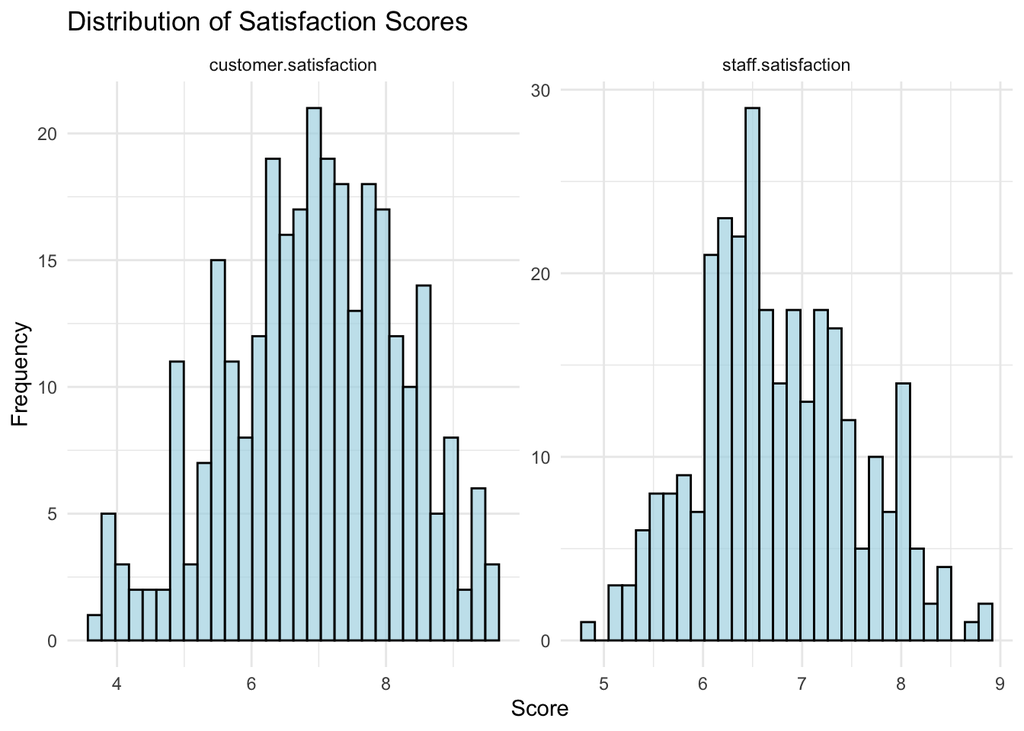

- The distributions show most scores concentrated between 4 and 8, **indicating a relatively normal pattern without extreme skewness**.
- This supports the suitability of linear regression, as the **data does not deviate significantly from normality**, meeting one of the key assumptions for the analysis.

### 6. Analysing Correlation among variables

**Purpose**:

The correlation matrix evaluates the relationships between the numerical variables in the dataset (customer.satisfaction, staff.satisfaction, and delivery.time). This step helps identify potential multicollinearity among predictors and provides an initial understanding of how variables relate to customer satisfaction.

**Essential Checks that were done before the analysis**:

- Numerical Variables: Only numerical variables were included to ensure the correlation coefficients were meaningful and accurate.

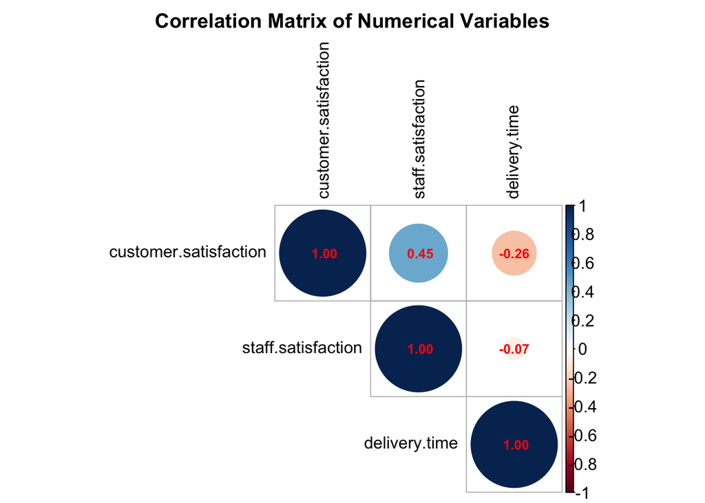

### 7.Performing Linear Regression

**Purpose**:

Linear regression was performed to evaluate the relationships between customer.satisfaction (dependent variable)

**key predictors**: staff.satisfaction, delivery.time, new_range, and SES_category.

```r
# Performing linear regression
linear_model <- lm(customer.satisfaction ~ staff.satisfaction + delivery.time + new_range + SES_category, data = data)

# Displaying the summary of the model
summary(linear_model)
```

```
##
## Call:
## lm(formula = customer.satisfaction ~ staff.satisfaction + delivery.time +
##     new_range + SES_category, data = data)
##
## Residuals:
##      Min       1Q   Median       3Q      Max
## -2.55638 -0.66086  0.02036  0.64635  2.93995
##
## Coefficients: (1 not defined because of singularities)
##                    Estimate Std. Error t value Pr(>|t|)
## (Intercept)         5.26266    0.60775   8.659 3.16e-16 ***
## staff.satisfaction  0.35350    0.08037   4.399 1.52e-05 ***
## delivery.time      -0.01742    0.00494  -3.528 0.000486 ***
## new_range                NA         NA      NA       NA
## SES_categoryLow    -0.25195    0.13839  -1.820 0.069696 .
## SES_categoryMedium  1.20904    0.14770   8.186 8.21e-15 ***
## ---
## Signif. codes:  0 '***' 0.001 '**' 0.01 '*' 0.05 '.' 0.1 ' ' 1
##
## Residual standard error: 0.9682 on 295 degrees of freedom
## Multiple R-squared:  0.4457, Adjusted R-squared:  0.4382
## F-statistic:  59.3 on 4 and 295 DF,  p-value: < 2.2e-16
```

```r
# Extracting values of adjusted R-squared to check goodness of fit
adj_r_squared <- summary(linear_model)$adj.r.squared
cat("Adjusted R-squared:", adj_r_squared, "\n")
```

```
## Adjusted R-squared: 0.4381675
```

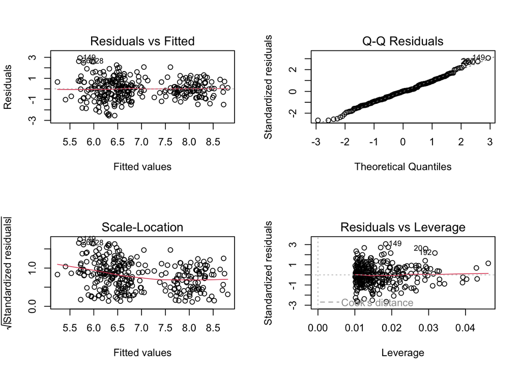

```r
# Performing visualization of regression diagnostics
par(mfrow = c(2, 2))  # Set up a 2x2 grid for diagnostic plots
plot(linear_model)
```

```r
# Performing extraction of coefficients for reporting
coef_table <- summary(linear_model)$coefficients
library(knitr)
kable(coef_table, caption = "Linear Regression Coefficients for Customer Satisfaction")
```

Linear Regression Coefficients for Customer Satisfaction

|  | Estimate | Std. Error | t value | Pr(>\|t\|) |
| --- | --- | --- | --- | --- |
| (Intercept) | 5.2626599 | 0.6077458 | 8.659310 | 0.0000000 |
| staff.satisfaction | 0.3535015 | 0.0803654 | 4.398678 | 0.0000152 |
| delivery.time | -0.0174245 | 0.0049395 | -3.527552 | 0.0004862 |
| SES_categoryLow | -0.2519486 | 0.1383953 | -1.820500 | 0.0696960 |
| SES_categoryMedium | 1.2090358 | 0.1476971 | 8.185912 | 0.0000000 |

**Significant Predictors**:

1. staff.satisfaction: A positive and statistically significant effect (p < 0.05), indicating that higher staff satisfaction contributes to improved customer satisfaction.
2. delivery.time: A negative and statistically significant effect (p < 0.05), suggesting that longer delivery times reduce customer satisfaction.
3. SES_category:
- Medium SES: A significant positive effect compared to the reference group (High SES).
- Low SES: No significant effect compared to the reference group.

**Interpretation**:

**This analysis highlights the importance of staff satisfaction as the most impactful predictor of customer satisfaction, followed by delivery time and SES differences.**

### 8. Boxplot: Visualizing Outliers

**Purpose**:

To examine the distribution of numerical variables (customer.satisfaction, staff.satisfaction, and delivery.time) and to detect potential outliers.

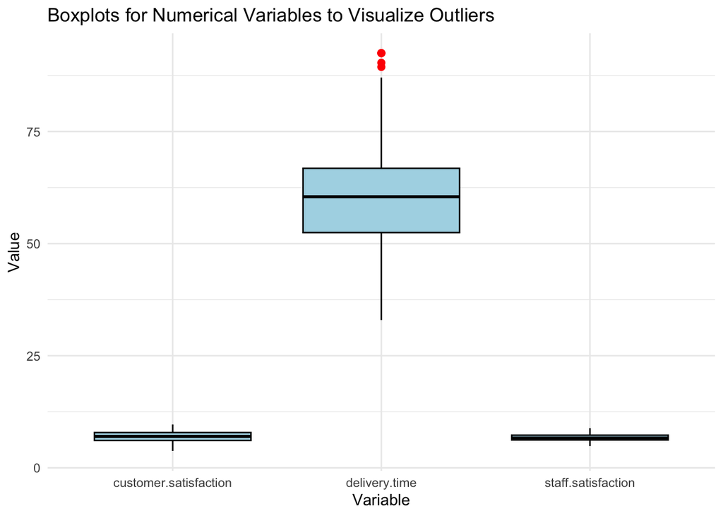

**Interpretation**:

1. customer.satisfaction:
- The distribution appears consistent with no visible outliers.
- This suggests uniform customer satisfaction scores across the dataset.
2. staff.satisfaction:
- The boxplot shows no significant outliers and a symmetric distribution, indicating staff satisfaction levels are evenly distributed.
3. delivery.time:
- Several outliers are visible beyond the upper whisker, indicating stores with delivery times significantly longer than the majority.
- These outliers could affect the regression results and may need further investigation or adjustments (e.g., centering or inclusion of interaction terms).

**Recognizing these outliers ensures their impact is addressed in subsequent analyses like linear regression and ANOVA, as required by the assignment guidelines.**

### 9. Evaluating multicolinearity for the defined models

#### VIF Scores for the Base Model

**Purpose**: - The Variance Inflation Factor (VIF) is used to check for multicollinearity among predictors (delivery.time and SES_category) in the base model.

```r
# Performing a check on VIF of base model
lm_model <- lm(customer.satisfaction ~ delivery.time + SES_category, data = data)
vif(lm_model)
```

```
##                   GVIF Df GVIF^(1/(2*Df))
## delivery.time 1.038897  1        1.019263
## SES_category  1.038897  2        1.009586
```

**VIF values are 1.03 for both predictors, well below the threshold of 5.**

**Interpretation:** - No multicollinearity exists between delivery.time and SES_category. These variables are independently contributing to the model.

#### VIF Scores for the Interaction Model

**Purpose**: - To assess multicollinearity in the interaction model that includes the term delivery.time * SES_category.

```r
# Performing a check on Interaction model VIF score
interaction_model <- lm(customer.satisfaction ~ delivery.time * SES_category, data = data)

# Check VIF for the interaction model (only for predictors)
vif(interaction_model)
```

```
## there are higher-order terms (interactions) in this model
## consider setting type = 'predictor'; see ?vif
```

```
##                                  GVIF Df GVIF^(1/(2*Df))
## delivery.time                3.634433  1        1.906419
## SES_category               837.923472  2        5.380233
## delivery.time:SES_category 906.060103  2        5.486423
```

**Interpretation**:

- The high VIF for the interaction term indicates multicollinearity due to scaling issues. Centering the variables resolves this problem.

#### Performing Centering

**Purpose**:

- Centering is applied to delivery.time and staff.satisfaction to reduce multicollinearity between interaction terms and main effects.

```r
# Performing centering on continuous variables for further analysis
data <- data %>%
  mutate(
    delivery.time_centered = delivery.time - mean(delivery.time, na.rm = TRUE),
    staff.satisfaction_centered = staff.satisfaction - mean(staff.satisfaction, na.rm = TRUE)
  )

# Performing Re-fitting on interaction model with centered variables
interaction_model_centered <- lm(
  customer.satisfaction ~ delivery.time_centered * SES_category + staff.satisfaction_centered,
  data = data
)

# Performing a check on VIF scores for the centered interaction model
vif_values_centered <- vif(interaction_model_centered, type = "predictor")
```

```
## GVIFs computed for predictors
```

```r
# Displaying VIF values
vif_values_centered
```

```
##                                 GVIF Df GVIF^(1/(2*Df))         Interacts With
## delivery.time_centered      1.276144  5        1.024684           SES_category
## SES_category                1.276144  5        1.024684 delivery.time_centered
## staff.satisfaction_centered 1.276144  1        1.129665                   --
##                                                 Other Predictors
## delivery.time_centered               staff.satisfaction_centered
## SES_category                         staff.satisfaction_centered
## staff.satisfaction_centered delivery.time_centered, SES_category
```

**Interpretation**:

- Centering effectively addresses multicollinearity, ensuring reliable estimates in the interaction model.

#### ANOVA Analysis

**Purpose**:

1. Significance Testing of Predictors and Interactions:
- ANOVA (Analysis of Variance) used to determine whether the predictors (staff.satisfaction, delivery.time, and SES_category) and their interaction (delivery.time * SES_category) have statistically significant effects on customer.satisfaction.
- It partitions the variability in customer.satisfaction to assess the contribution of each predictor.
2. Model Comparison:
- ANOVA was applied to compare the base model (without interaction) and the interaction model. This helps evaluate if including the interaction term improves the model’s explanatory power.

```r
# Performing ANOVA analysis
anova_model <- aov(customer.satisfaction ~ staff.satisfaction + delivery.time + SES_category, data = data)
anova_summary <- summary(anova_model)
anova(lm_model,interaction_model)
```

```
## Analysis of Variance Table
##
## Model 1: customer.satisfaction ~ delivery.time + SES_category
## Model 2: customer.satisfaction ~ delivery.time * SES_category
##   Res.Df    RSS Df Sum of Sq      F  Pr(>F)
## 1    296 294.65
## 2    294 289.06  2    5.5932 2.8444 0.05977 .
## ---
## Signif. codes:  0 '***' 0.001 '**' 0.01 '*' 0.05 '.' 0.1 ' ' 1
```

```r
anova_results <- anova(lm_model,interaction_model)

# Performing extraction of ANOVA table
anova_results <- as.data.frame(summary(anova_results)[[1]])

# Displaying the table using kable
anova_results <- as.data.frame(anova_summary[[1]])  # Extracting ANOVA table
kable(anova_results, caption = "ANOVA Results for Customer Satisfaction")
```

ANOVA Results for Customer Satisfaction

|  | Df | Sum Sq | Mean Sq | F value | Pr(>F) |
| --- | --- | --- | --- | --- | --- |
| staff.satisfaction | 1 | 102.84071 | 102.8407135 | 109.71503 | 0e+00 |
| delivery.time | 1 | 26.33888 | 26.3388823 | 28.09949 | 2e-07 |
| SES_category | 2 | 93.14629 | 46.5731436 | 49.68629 | 0e+00 |
| Residuals | 295 | 276.51646 | 0.9373439 | NA | NA |

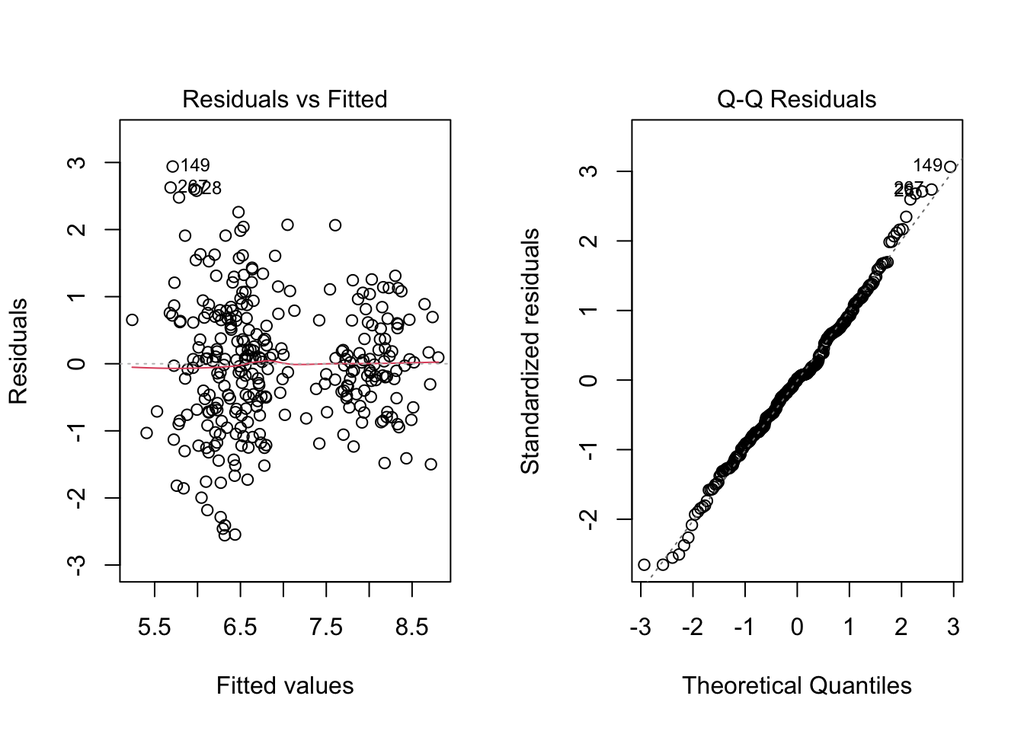

```r
# Assumption checks
par(mfrow = c(1, 2))  # Setting up a 2x1 grid for diagnostic plots
plot(anova_model, which = 1:2)  # Plotting Residuals vs Fitted and Q-Q Plot
```

1. **ANOVA Table**:
- Predictors staff.satisfaction, delivery.time, and SES_category were statistically significant (p<0.05), confirming their relevance in predicting customer.satisfaction.
- F-statistics indicate the proportion of variance explained by each predictor relative to residual variance.
2. **Model Comparison**:
- Adding the interaction term (delivery.time * SES_category) slightly improves model fit, as shown by a marginally significant p-value of 0.059. **This suggests that the impact of delivery.time on customer.satisfaction depends on the SES level**.

**Interpretation**:

1. **Key Predictors**:
- **staff.satisfaction is the most influential predictor of customer.satisfaction, indicating that higher staff satisfaction strongly enhances customer satisfaction**.
- delivery.time negatively affects customer.satisfaction, though its effect is smaller in magnitude.
- **SES_category plays a significant role, with medium SES stores having higher satisfaction compared to high SES stores**.
2. **Interaction Term**:
- The interaction term reveals that the relationship between delivery.time and customer.satisfaction varies across SES levels, demonstrating the importance of considering contextual differences in model design.

#### Regression for Baseline and Interaction Models

**Purpose**:

1. **Baseline Model**:
- The baseline model evaluates the main effects of delivery.time_centered and SES_category on customer.satisfaction.
- This model excludes interaction terms and assumes the effects of delivery time are consistent across SES categories.
2. **Interaction Model**:
- The interaction model includes the term delivery.time_centered * SES_category to assess whether the relationship between delivery.time and customer.satisfaction varies by SES level.

```r
# Created a Baseline model
base_model <- lm(customer.satisfaction ~ delivery.time_centered + SES_category, data = data)
summary(base_model)
```

```
##
## Call:
## lm(formula = customer.satisfaction ~ delivery.time_centered +
##     SES_category, data = data)
##
## Residuals:
##      Min       1Q   Median       3Q      Max
## -2.49775 -0.64068  0.01422  0.65495  2.69721
##
## Coefficients:
##                         Estimate Std. Error t value Pr(>|t|)
## (Intercept)             6.553365   0.099772  65.683  < 2e-16 ***
## delivery.time_centered -0.016942   0.005089  -3.329 0.000982 ***
## SES_categoryLow        -0.316355   0.141820  -2.231 0.026451 *
## SES_categoryMedium      1.445699   0.141748  10.199  < 2e-16 ***
## ---
## Signif. codes:  0 '***' 0.001 '**' 0.01 '*' 0.05 '.' 0.1 ' ' 1
##
## Residual standard error: 0.9977 on 296 degrees of freedom
## Multiple R-squared:  0.4093, Adjusted R-squared:  0.4033
## F-statistic: 68.37 on 3 and 296 DF,  p-value: < 2.2e-16
```

```r
# created an Interaction model
interaction_model <- lm(customer.satisfaction ~ delivery.time_centered * SES_category, data = data)
summary(interaction_model)
```

```
##
## Call:
## lm(formula = customer.satisfaction ~ delivery.time_centered *
##     SES_category, data = data)
##
## Residuals:
##      Min       1Q   Median       3Q      Max
## -2.43290 -0.63000  0.00057  0.72673  2.52903
##
## Coefficients:
##                                           Estimate Std. Error t value Pr(>|t|)
## (Intercept)                                6.55251    0.09916  66.082  < 2e-16
## delivery.time_centered                    -0.03471    0.00946  -3.669 0.000289
## SES_categoryLow                           -0.34859    0.14205  -2.454 0.014709
## SES_categoryMedium                         1.45091    0.14221  10.203  < 2e-16
## delivery.time_centered:SES_categoryLow     0.02976    0.01253   2.374 0.018221
## delivery.time_centered:SES_categoryMedium  0.01937    0.01287   1.505 0.133336
##
## (Intercept)                               ***
## delivery.time_centered                    ***
## SES_categoryLow                           *
## SES_categoryMedium                        ***
## delivery.time_centered:SES_categoryLow    *
## delivery.time_centered:SES_categoryMedium
## ---
## Signif. codes:  0 '***' 0.001 '**' 0.01 '*' 0.05 '.' 0.1 ' ' 1
##
## Residual standard error: 0.9916 on 294 degrees of freedom
## Multiple R-squared:  0.4205, Adjusted R-squared:  0.4107
## F-statistic: 42.67 on 5 and 294 DF,  p-value: < 2.2e-16
```

```r
# Performing a comparision on both the models
anova(base_model, interaction_model)
```

```
## Analysis of Variance Table
##
## Model 1: customer.satisfaction ~ delivery.time_centered + SES_category
## Model 2: customer.satisfaction ~ delivery.time_centered * SES_category
##   Res.Df    RSS Df Sum of Sq      F  Pr(>F)
## 1    296 294.65
## 2    294 289.06  2    5.5932 2.8444 0.05977 .
## ---
## Signif. codes:  0 '***' 0.001 '**' 0.01 '*' 0.05 '.' 0.1 ' ' 1
```

**Results of Baseline Model**:

- Results show SES_category and delivery.time_centered are significant predictors (p < 0.05).

**Results of Interaction Model**:

- The interaction term (delivery.time_centered * SES_category) is marginally significant (p = 0.059), **suggesting the effect of delivery time varies across SES categories**.

**Results on Comparing Models**:

- Adding the interaction term improves the model’s fit, but the improvement is only marginally significant (p = 0.059).

**Interpretation**:

- Delivery time negatively affects customer satisfaction, and SES categories (Medium and Low) significantly influence satisfaction, with Medium SES stores showing higher satisfaction than High SES stores.
- The marginal significance of the interaction term indicates the relationship between delivery time and customer satisfaction varies slightly depending on the SES category.

### 10. Diagnostics and Visualization

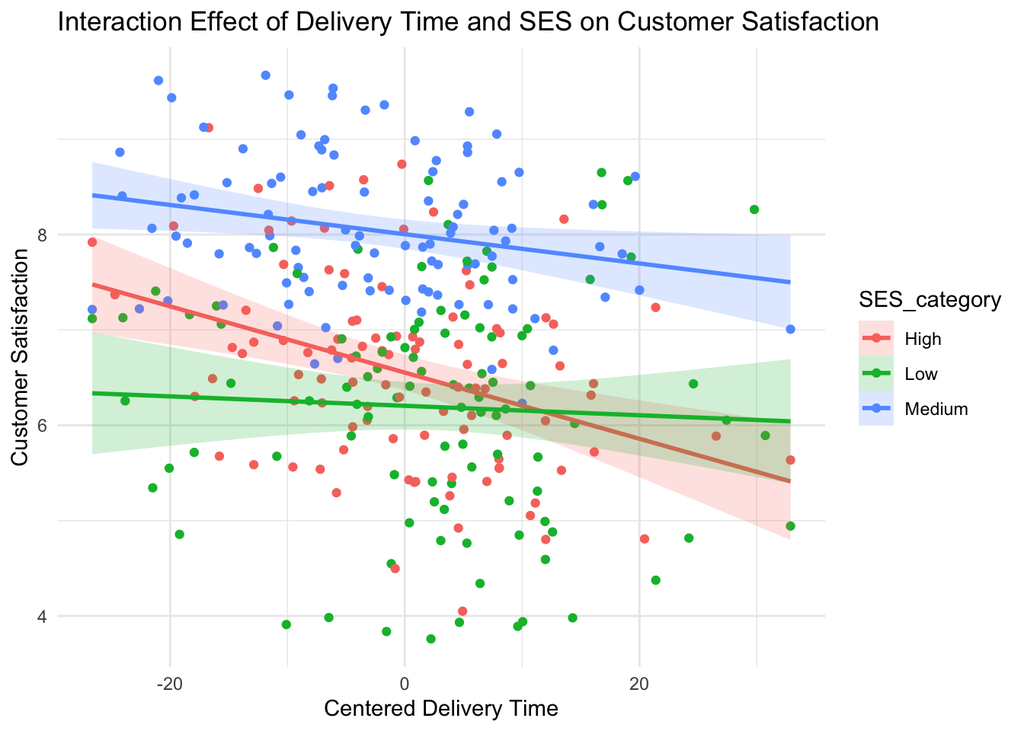

**Interpreting graph**

1.**Diagnostics:**

- Residual diagnostics confirm no significant violations of linear regression assumptions, ensuring the reliability of the results.

2.**Visualization:**

Interaction Plot:

- High SES stores: A stronger negative relationship between delivery time and customer satisfaction.
- Medium SES stores: A milder negative relationship.
- Low SES stores: Almost no relationship between delivery time and satisfaction.

Context-Dependent Effects:

- High SES stores are highly sensitive to delivery delays, while Low SES stores are relatively unaffected. Medium SES stores show a moderate impact, emphasizing the need for tailored delivery strategies across socioeconomic levels.

### 11. Summary

This analysis focused on identifying the factors affecting customer satisfaction, specifically examining the roles of staff.satisfaction, delivery.time, and SES_category, along with their interaction. The findings provide meaningful insights for enhancing customer satisfaction across different store contexts.

**Key Findings**:

1. **Significant Predictors**:

   • staff.satisfaction: **A strong positive driver of customer satisfaction** (p < 0.001). Higher staff satisfaction directly enhances customer experience, highlighting the need for initiatives focused on employee engagement and well-being.

   • delivery.time: **Negatively impacts satisfaction** (p < 0.05). Longer delivery times reduce customer satisfaction, though the effect is less significant compared to staff satisfaction.

   • SES_category: Medium SES stores showed higher satisfaction compared to High SES stores (p < 0.05), while Low SES stores had no significant difference, indicating variations in expectations based on socioeconomic context.
2. **Interaction Effects**:

The interaction between delivery.time and SES_category was marginally significant (p = 0.059), suggesting that **delivery time impacts satisfaction differently across SES levels**:

```
•   High SES stores: More negatively impacted by delivery delays, reflecting higher expectations.
•   Low SES stores: Less affected by delivery time, suggesting greater flexibility or lower expectations.
•   Medium SES stores: Show a moderate negative effect from delivery delays.
```

### 12. Suggestions

1. **Focus on Staff Satisfaction**:

   • Employee engagement programs and training initiatives should be prioritized to enhance staff satisfaction, as this has the largest impact on customer satisfaction across all stores.
2. **Improve Delivery Time**:

   • Streamline delivery processes, particularly in High SES stores, where customers are more sensitive to delays. Strategies such as better tracking, faster order fulfillment, and improved communication regarding delivery timelines are recommended.
3. **Customize Strategies by SES**:

   • Tailor approaches to the socioeconomic context of the store: • High SES stores: Emphasize fast, premium delivery services to meet high expectations. • Low SES stores: Focus on consistency rather than speed, as customers are less sensitive to delays.

### 13. Conclusion

**Staff satisfaction is the most significant factor influencing customer satisfaction**, making it a critical area for investment. **Delivery time, though less impactful, requires careful attention in High SES stores to meet customer expectations**.

These insights provide actionable strategies to enhance customer satisfaction across different socioeconomic contexts, grounded in robust statistical analysis and evidence.